# Homeless Children in Arkansas

Rob Wells, Ph.D.

3/28/2020

## Reporting on Homelessness: Data Analysis for Journalists

#### Jour 405v, Jour 5003, Spring 2020

# Part 1: Homeless Children Data

Load tidyverse, janitor, lubidate

Load Data

Clean up column names to they are R friendly

```r
ChildrenAR <- janitor::clean_names(ChildrenAR)
```

- **Run a summary of the homeless data.**

What is the median homeless percentage?  
What is the average (mean)?  
What is the maximum?

```r
summary(ChildrenAR$district_percent_homeless)
```

```
##     Min.  1st Qu.   Median     Mean  3rd Qu.     Max.     NA's
## 0.000000 0.006212 0.020501 0.035909 0.047251 0.226866        1
```

- **Create a table with all school districts with more than 10% homeless**

HINT: SEE THE R_Intro_Jan15, the code for “Build a table with all counties above that median income”

```r
  ChildrenAR %>%
  select(district_name, district_percent_homeless) %>%
  filter(district_percent_homeless >= .10) %>%
  arrange(desc(district_percent_homeless))
```

```
##                           district_name district_percent_homeless
## 1           GUY-PERKINS SCHOOL DISTRICT                 0.2268657
## 2              BRADFORD SCHOOL DISTRICT                 0.2032333
## 3  FRIENDSHIP ASPIRE ACADEMY PINE BLUFF                 0.1964286
## 4       WEST SIDE SCHOOL DIST(CLEBURNE)                 0.1869565
## 5               FLIPPIN SCHOOL DISTRICT                 0.1793103
## 6                JASPER SCHOOL DISTRICT                 0.1770956
## 7           BLYTHEVILLE SCHOOL DISTRICT                 0.1580790
## 8                ALPENA SCHOOL DISTRICT                 0.1558935
## 9               CLINTON SCHOOL DISTRICT                 0.1427432
## 10     MT. VERNON/ENOLA SCHOOL DISTRICT                 0.1419878
## 11              HAMPTON SCHOOL DISTRICT                 0.1396161
## 12            LEAD HILL SCHOOL DISTRICT                 0.1384181
## 13                PARIS SCHOOL DISTRICT                 0.1379981
## 14               HECTOR SCHOOL DISTRICT                 0.1336806
## 15          COUNTY LINE SCHOOL DISTRICT                 0.1331967
## 16         CROSS COUNTY SCHOOL DISTRICT                 0.1329879
## 17             BRINKLEY SCHOOL DISTRICT                 0.1320346
## 18           BOONEVILLE SCHOOL DISTRICT                 0.1251057
## 19           BERRYVILLE SCHOOL DISTRICT                 0.1233457
## 20              HACKETT SCHOOL DISTRICT                 0.1230159
## 21        JUNCTION CITY SCHOOL DISTRICT                 0.1204268
## 22                OMAHA SCHOOL DISTRICT                 0.1137566
## 23              NEWPORT SCHOOL DISTRICT                 0.1136767
## 24              NORFORK SCHOOL DISTRICT                 0.1132075
```

Create Children10 table, from code above, table with all school districts with more than 10% homeless

```r
Children10 <- ChildrenAR %>%
  select(district_name, district_percent_homeless) %>%
  filter(district_percent_homeless >= .10) %>%
  arrange(desc(district_percent_homeless))
```

## Change Over Time

For your reference! https://profrobwells.github.io/HomelessSP2020/SF_311_Calls_UofA.html

Import 2013-14 homeless data, call it ChildrenAR2013, clean the labels

```r
ChildrenAR2013 <- rio::import("https://github.com/profrobwells/HomelessSP2020/blob/master/Data/2013-2014-demographics-data-for-districts-2.xlsx?raw=true", which = "Data", skip=8)
```

```
## * `` -> ...1
```

```r
# Clean up column names to they are R friendly
ChildrenAR2013 <- janitor::clean_names(ChildrenAR2013)
```

- **Create a table with just the district name and the homeless data for 2018-19**

Call it table2018

```r
table2018 <- ChildrenAR %>%
  select(district_name, district_percent_homeless, district_lea) %>%
  arrange(desc(district_percent_homeless))
```

Rename a column name

```r
colnames(Children10)[2] <- "Pct_Homeless_2018"
#It takes the second column in Children10 and assigns the new name #"Pct_Homeless_2018"
names(Children10)
```

```
## [1] "district_name"     "Pct_Homeless_2018"
```

- **Rename the appropriate table2018 column to “Pct_Homeless_2018”**

```r
colnames(table2018)[2] <- "Pct_Homeless_2018"
```

- **Follow the same steps for the 2013 data:** Create table2013 Rename the appropriate table2013 column to “Pct_Homeless_2013”

```r
table2013 <- ChildrenAR2013 %>%
  select(district_name, district_percent_homeless,  district_lea) %>%
  arrange(desc(district_percent_homeless))
#
colnames(table2013)[2] <- "Pct_Homeless_2013"
#
#convert all text to lowercase
#table2013$district_name <- tolower(table2013$district_name)
```

- **Joining Tables**

```r
newtable <- table2018 %>%
  inner_join(table2013, by=("district_lea"))
```

- **How many records were left out?**  
  8 Records.  
  Use anti_join to determine the 2013 records not in 2018

```r
table2013 %>%
  anti_join(table2018, by=("district_lea"))
```

```
##                                               district_name
## 1                                  HARTFORD SCHOOL DISTRICT
## 2                                    HUGHES SCHOOL DISTRICT
## 3                                        LISA ACADEMY NORTH
## 4                                  NORPHLET SCHOOL DISTRICT
## 5 RESPONSIVE ED SOLUTIONS QUEST MIDDLE SCHOOL OF PINE BLUFF
## 6                                  STEPHENS SCHOOL DISTRICT
## 7                               OZARK UNLITD RESOURCE CO-OP
## 8                               WILBUR D. MILLS EDUC. CO-OP
##   Pct_Homeless_2013 district_lea
## 1              0.11      6604000
## 2              0.00      6202000
## 3              0.00      6048700
## 4              0.00      7006000
## 5              0.00      3542700
## 6              0.00      5206000
## 7                NA       520000
## 8                NA      7320000
```

Making a table with the same thing above

```r
leftout <- table2013 %>%
  anti_join(table2018, by=("district_lea"))
```

- **Math!**

This creates a new column with the percentage point difference

```r
newtable <- newtable %>%
  mutate(difference = Pct_Homeless_2018-Pct_Homeless_2013)
```

- **Produce a table with top 20 schools with the greatest increase in student homelessness since 2013, measured by percentage point difference**

```r
top10worst <-  newtable %>%
  top_n(20, difference) %>%
  arrange(desc(difference))
```

# Basic Map Exercise

- **We will create a map of homeless children by schools in Arkansas**

This lesson references the Machlis Ch 11 map exercise as a template. It also references Andrew Ba Tran’s map tutorial https://github.com/profrobwells/HomelessSP2020/blob/master/Readings/Tran%20-%20Geolocating.pdf

#### HERE WE GO!

Use ChildrenAR Join ChildrenAR with addresses

Load Addresses

```r
School_Address <- rio::import("https://github.com/profrobwells/HomelessSP2020/blob/master/Data/SDI%20Districts%20Printed-02-26-2020-11_38_05.xlsx?raw=true", skip =1)
```

Convert School address LEA to numeric and match

```r
School_Address$LEA <- as.numeric(School_Address$LEA)
ChildrenAR$LEA <- ChildrenAR$district_lea
```

Now we join School_Address to ChildrenAR

```r
abc <- School_Address %>%
  select(LEA, Name, Address) %>%
  inner_join(ChildrenAR, by="LEA")
```

#QUESTION: How many records in new combined dataframe? What is the difference?

```r
abc_not <- School_Address %>%
  select(LEA, Name, Address) %>%
  anti_join(ChildrenAR, by="LEA")
```

Df with 261. which ones dropped? Lost two

NEXT, we geocode the addresses using mutate_geocode This is a little involved…

What I did: ?register_google Google API Key https://www.youtube.com/watch?v=1JNwpp5L4vM https://console.cloud.google.com/apis/credentials?folder=&organizationId=&project=phonic-botany-269820 register_google(key = “MY TOP SECRET KEY”) schools_geocoded <- mutate_geocode(abc, Address) write.csv(schools_geocoded, “schools_geocoded.csv”)

- **Shortcut!!!**

Next: Simplify the school district names

```r
schools_geocoded$Name_Cleaned <- gsub("SCHOOL", "", schools_geocoded$Name)
```

```r
schools_geocoded$Name_Cleaned <- gsub("DISTRICT", "", schools_geocoded$Name)
```

```r
schools_geocoded$Name_Cleaned <- gsub("SCHOOL", "", schools_geocoded$Name_Cleaned)
```

Load map town shapes for Arkansas with Tigris.

If you don’t have tigris or ggplot2 or sf installed yet, uncomment and run the line below

```r
# set sf option
options(tigris_class = "sf")
options(tigris_use_cache = TRUE)
```

And we finally load the school district boundary map

Basic Map of School Districts

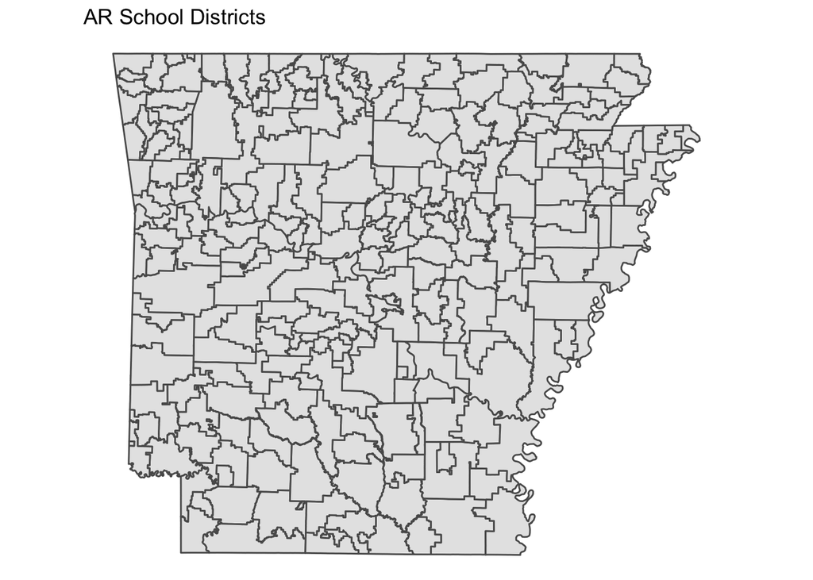

```r
ggplot(ar_schools) +
  geom_sf() +
  theme_void() +
  theme(panel.grid.major = element_line(colour = 'transparent')) + labs(title="AR School Districts")
```

Adding layer with homeless data

```r
set.seed(25)
```

We create a temporary table “bf” that has the district school names, percent homeless, the lon, lat and filtered for districts with more that 10% homeless

```r
bf<- schools_geocoded %>%
  select(district_name, Name_Cleaned, district_percent_homeless, lon, lat) %>%
  filter(district_percent_homeless >= .10)
```

Plot map with subset data

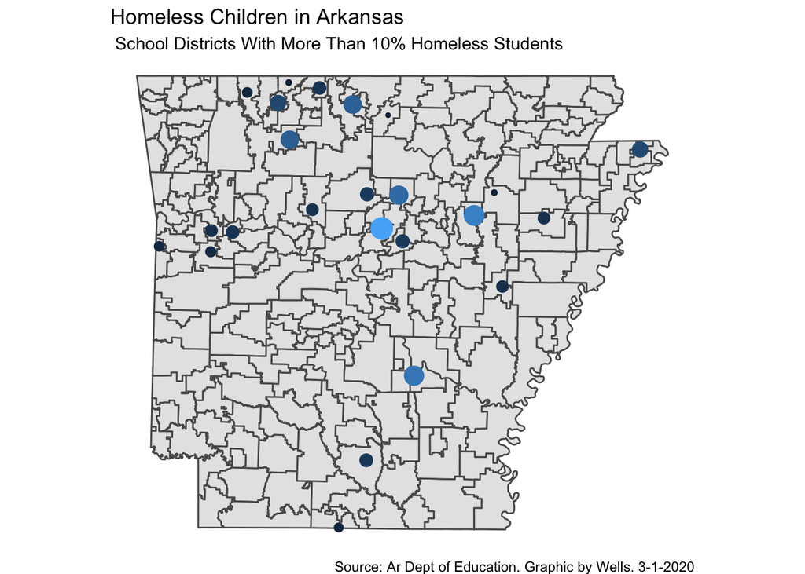

```r
ggplot(ar_schools) +
  geom_sf() +
  geom_point(data=bf, aes(x=lon, y=lat, size=district_percent_homeless, color=district_percent_homeless), show.legend = FALSE) +
  theme_void() +
  theme(panel.grid.major = element_line(colour = 'transparent')) +
  labs(title="Homeless Children in Arkansas",
       subtitle = " School Districts With More Than 10% Homeless Students",
       caption = "Source: Ar Dept of Education. Graphic by Wells. 3-1-2020")
```

Clean it up!

```r
bf <- janitor::clean_names(bf)
```

Plot with labels

```r
library(ggrepel)
```

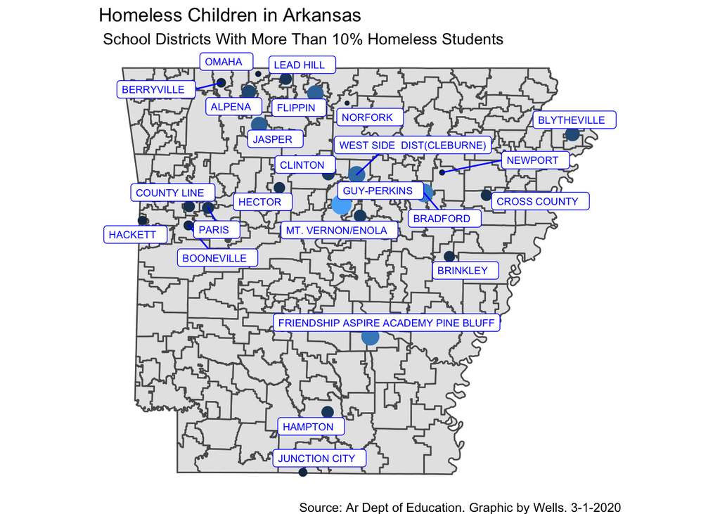

```r
ggplot(ar_schools) +
  geom_sf() +
  geom_point(data=bf, aes(x=lon, y=lat,
                          size=district_percent_homeless, color=district_percent_homeless),
             show.legend = FALSE) +
  geom_label_repel(data=bf, aes(x=lon, y=lat, label = name_cleaned), size=2.5, color="blue") +
  theme_void() +
  theme(panel.grid.major = element_line(colour = 'transparent')) +
  labs(title="Homeless Children in Arkansas",
       subtitle = " School Districts With More Than 10% Homeless Students",
       caption = "Source: Ar Dept of Education. Graphic by Wells. 3-1-2020")
```

- **Task:Create a dataframe with the top 10 districts with the largest percentage increase in homelessness since 2013 and map it.**

# Homeless Children Data Analysis

#March 14, 2019

In this section, we analyze homeless children data over time and compare previous years of homeless children data. –Take the 2018-2019 data and compare to the 2014-2015 data –Following the same workflow in the Census exercise, import the two datasets, rename the columns, clean the district names, calculate percentage change in homeless 1) –Produce a table with statewide changes in homelessness and the special needs index from 2018-2019 vs 2014-2015. 2) –Produce a smaller chart with all of the districts you have contacted

## Part 1: import the two datasets, rename the columns, clean the district names

ChildrenAR is already loaded from above. Rename as ChildAR2019

```r
ChildAR2019 <- ChildrenAR
```

Rename columns anticipating merge with older data

```r
colnames(ChildAR2019)[3] <- c("enroll_2019")
colnames(ChildAR2019)[5:6] <- c("special_ed_pct_2019", "homeless_pct_2019")
```

Load ChildrenAR 2014-15 data, clean and rename

```r
ChildAR2015 <- rio::import("https://github.com/profrobwells/HomelessSP2020/blob/master/Data/2014-2015-demographics-for-districts.xlsx?raw=true", which = "Data", skip=8)
```

```
## * `` -> ...1
```

```r
ChildAR2015 <- janitor::clean_names(ChildAR2015)
colnames(ChildAR2015)[3] <- c("enroll_2015")
colnames(ChildAR2015)[5:6] <- c("special_ed_pct_2015", "homeless_pct_2015")
```

SELECT SUBSET WITH DISTRICT NAME POVERTY SPECIAL NEEDS ENROLLMENT AND MERGE Merge Census Data

```r
temp <- ChildAR2019 %>%
  inner_join(ChildAR2015, by=("district_lea"))
```

Boil it down

```r
Child2019_15 <- temp %>%
  select(district_name.x, enroll_2019, enroll_2015, special_ed_pct_2019, special_ed_pct_2015,
                       homeless_pct_2019, homeless_pct_2015, district_lea)
colnames(Child2019_15)[1] <- c("district")
```

Simplify the school district names Backup distict name

```r
Child2019_15$district_bak <- Child2019_15$district
Child2019_15$district <- gsub("SCHOOL", "", Child2019_15$district)
Child2019_15$district  <- gsub("DISTRICT", "", Child2019_15$district)
Child2019_15$district <- gsub("SCHOOL", "", Child2019_15$district)
Child2019_15$district <- gsub(" ", "", Child2019_15$district)
```

Part 2: Calculate calculate percentage change in homeless: How has homeless changed from 2015-19?

```r
Child2019_15 <- Child2019_15 %>%
  mutate(homeless_pct_diff = (homeless_pct_2019-homeless_pct_2015)/homeless_pct_2015) %>%
  arrange(desc(homeless_pct_diff))
```

```r
library(formattable)

Child2019_15$homeless_pct_diff <- percent(Child2019_15$homeless_pct_diff)
```

How has special needs changed from 2015-19

```r
Child2019_15 <- Child2019_15 %>%
  mutate(special_pct_diff = (special_ed_pct_2019-special_ed_pct_2015)/special_ed_pct_2015) %>%
  arrange(desc(special_pct_diff))

library(formattable)

Child2019_15$special_pct_diff <- percent(Child2019_15$special_pct_diff)
```

–Produce a table with statewide changes in homelessness and the special needs index from 2018-2019 vs 2014-1025.

```r
Child2019_15 %>%
  select(district, homeless_pct_diff, special_pct_diff)
```

```
##                               district homeless_pct_diff special_pct_diff
## 1    RESPONSIVEEDUCATIONSOLUTIONSQUEST               Inf              Inf
## 2     EXALTACADEMYOFSOUTHWESTLITTLEROC               NaN              Inf
## 3                            DOLLARWAY               Inf          114.71%
## 4     RESPONSIVEEDSOLUTIONSPREMIERHIGH          -100.00%           96.12%
## 5                             BRADFORD           352.19%           93.59%
## 6    RESPONSIVEEDSOLUTIONSNORTHWESTARK               NaN           82.90%
## 7                       IMBODENCHARTER           -87.95%           80.79%
## 8                     KIPPDELTAPUBLICS            80.58%           78.72%
## 9               ARKANSASVIRTUALACADEMY            86.02%           68.79%
## 10                         LISAACADEMY           -70.18%           68.09%
## 11                             FORDYCE           392.41%           64.14%
## 12                     MAGNETCOVEDIST.           -54.59%           62.03%
## 13                             MIDLAND          3450.39%           61.57%
## 14                          SPRINGHILL            -6.71%           56.49%
```

[output cut: 240 more lines]

Save to a table

```r
Child2019_15_summary <- Child2019_15 %>%
  select(district, homeless_pct_diff, special_pct_diff)
```

Your schools

```r
Child2019_15 %>%
filter(district=="BERRYVILLE" | district=="JASPER" | district=="LEADHILL")
```

```
##     district enroll_2019 enroll_2015 special_ed_pct_2019
## 1     JASPER         847         876           0.1416765
## 2 BERRYVILLE        1889        2054           0.1646374
## 3   LEADHILL         354         368           0.1553672
##   special_ed_pct_2015 homeless_pct_2019 homeless_pct_2015 district_lea
## 1           0.1038813         0.1770956       0.045662100      5102000
## 2           0.1212269         0.1233457       0.009250243       801000
## 3           0.1494565         0.1384181       0.032608696       506000
##                 district_bak homeless_pct_diff special_pct_diff
## 1     JASPER SCHOOL DISTRICT           287.84%           36.38%
## 2 BERRYVILLE SCHOOL DISTRICT          1233.43%           35.81%
## 3  LEAD HILL SCHOOL DISTRICT           324.48%            3.95%
```

## Notes Beyond this point

install.packages(“ggpubr”) library(“ggpubr”)

cor(x, y, method = c(“pearson”, “kendall”, “spearman”)) cor.test(x, y, method=c(“pearson”, “kendall”, “spearman”))

res <- cor.test(Child2019_15$homeless_pct_2019, Child2019_15$special_ed_pct_2019, method = “pearson”)

res